# An overview of the COPASutils package

In this example, the COPASutils package will be used to read in, process, and analyze data resulting from a Genome Wide Association Study (GWAS) using *Caenorhabditis elegans* nematode worms and a COPAS BIOSORT large particle flow cytometer. This example assumes that the COPASutils package is installed, with all necessary dependencies on your local machine. To install the COPASutils package, you can use the command `install.packages("COPASutils")`.

> **Note:** Some of the commands below will produce warnings when executed on a local machine. The warnings describe issues such as missing or strange values fed to the underlying functions and should not alarm the user. Warnings have been suppressed in this vignette for the sake of aesthetics.

The COPASutils will package first be loaded so that we can utilize the associated functions and example data:

```r
library(COPASutils)
```

## Reading Data

> **Note:** All of the raw .txt files referenced below are available at https://github.com/AndersenLab/COPASutils-data

We can now read in the plate data from one of the example data sets. In this GWAS experimental design, each plate is set up with three worms sorted to each well in every other column. An example data set, called “plateData1.txt”, that illustrates this step of the experiment is available from the Andersen Laboratory website (andersenlab.org). This text file is a representative example of raw data collected from a Union Biometrica BIOSORT large particle flow cytometer with ReFLx sampler. We will first read this file in and save it to a data frame called `setupRaw`:

```r
setupRaw <- readPlate("plateData1.txt")
```

If we look at the head of this data frame we can begin to step through the different data that are output by the COPAS machine:

```r
head(setupRaw)
```

```
## Source: local data frame [6 x 15]
## Groups: row, col
##
##   row col sort TOF EXT time green yellow red norm.EXT norm.green norm.yellow norm.red object call50
## 1   A   1    6 341 206    0    42     57  44   0.6041    0.12317     0.16716  0.12903 1.0000 object
## 2   A   1    6 345 226   62    57     61  44   0.6551    0.16522     0.17681  0.12754 1.0000 object
## 3   A   1    2  53  29  421    10      4   5   0.5472    0.18868     0.07547  0.09434 0.9987 object
## 4   A   1    6 341 185  452    60     64  47   0.5425    0.17595     0.18768  0.13783 1.0000 object
## 5   A   1    0 487 193  858    47     47  38   0.3963    0.09651     0.09651  0.07803 1.0000 object
## 6   A   1    0  58  17  920     3      3   4   0.2931    0.05172     0.05172  0.06897 0.9989 object
```

If you would like to remove the last two columns (i.e. read in data without the help of the SVM), you can set the `SVM` argument to FALSE, as below:

```r
setupRaw2 <- readPlate("plateData1.txt", SVM=FALSE)
head(setupRaw2)
```

```
## Source: local data frame [6 x 13]
## Groups: row, col
##
##   row col sort TOF EXT time green yellow red norm.EXT norm.green norm.yellow norm.red
## 1   A   1    6 341 206    0    42     57  44   0.6041    0.12317     0.16716  0.12903
## 2   A   1    6 345 226   62    57     61  44   0.6551    0.16522     0.17681  0.12754
## 3   A   1    2  53  29  421    10      4   5   0.5472    0.18868     0.07547  0.09434
## 4   A   1    6 341 185  452    60     64  47   0.5425    0.17595     0.18768  0.13783
## 5   A   1    0 487 193  858    47     47  38   0.3963    0.09651     0.09651  0.07803
## 6   A   1    0  58  17  920     3      3   4   0.2931    0.05172     0.05172  0.06897
```

We can also set cutoffs for minimum and maximum time of flight and extinction values as such:

```r
setupRaw3 <- readPlate("plateData1.txt", tofmin=60, tofmax=1000, extmin=50, extmax=500)
head(setupRaw3)
```

```
## Source: local data frame [6 x 15]
## Groups: row, col
##
##   row col sort TOF EXT time green yellow red norm.EXT norm.green norm.yellow norm.red object call50
## 1   A   1    6 341 206    0    42     57  44   0.6041    0.12317     0.16716  0.12903      1 object
## 2   A   1    6 345 226   62    57     61  44   0.6551    0.16522     0.17681  0.12754      1 object
## 3   A   1    6 341 185  452    60     64  47   0.5425    0.17595     0.18768  0.13783      1 object
## 4   A   1    0 487 193  858    47     47  38   0.3963    0.09651     0.09651  0.07803      1 object
## 5   A   1    0 257 248 2012    66     77  60   0.9650    0.25681     0.29961  0.23346      1 object
## 6   A   1    0 469 259 2199    63     70  57   0.5522    0.13433     0.14925  0.12154      1 object
```

Lastly, we can read in a data file from a BioSorter machine, which utilizes the LP Sampler instead of the BIOSORT machine’s ReFLx module. We can adjust the way in which the file is read to compensate for this difference by setting the `reflx` parameter to `FALSE`:

```r
biosorterData <- readPlate("BioSorter.txt", reflx=FALSE)
head(biosorterData)
```

```
## Source: local data frame [6 x 15]
## Groups: row, col
##
##   row col sort TOF   EXT time green yellow  red norm.EXT norm.green norm.yellow norm.red object call50
## 1   A   1    0 480 356.0    0  2.70   1.65 2.33   0.7417   0.005625    0.003438 0.004854 1.0000 object
## 2   A   1    0 138  29.9   95  0.51   0.39 0.41   0.2167   0.003696    0.002826 0.002971 0.9999 object
## 3   A   1    0  40   1.2  931  0.11   0.11 0.11   0.0300   0.002750    0.002750 0.002750 0.3757 bubble
## 4   A   1    0 280  71.0  973  8.25   1.06 3.47   0.2536   0.029464    0.003786 0.012393 1.0000 object
## 5   A   1    0 264  61.6 1125 11.80   1.14 2.65   0.2333   0.044697    0.004318 0.010038 1.0000 object
## 6   A   1    0 492  55.8 1195 11.00   1.85 6.03   0.1134   0.022358    0.003760 0.012256 1.0000 object
```

[output not shown]

## Processing Data

Now that we have read our raw data into R using the `readPlate` function, we probably want to summarize the data by well. We are not necessarily interested in the data at the per object level, but it would be nice to get some summary statistics for each well. For instance, in the GWAS experiment from we which are examining the data, it is desired that 3 worms be sorted into each well in every other column. To summarize the data we can use the `summarizePlate` function:

```r
setupSummarized <- summarizePlate(setupRaw)
colnames(setupSummarized)
```

```
##  [1] "row"                "col"                "n"                  "n.sorted"           "mean.TOF"
##  [6] "median.TOF"         "mean.EXT"           "median.EXT"         "mean.red"           "median.red"
## [11] "mean.green"         "median.green"       "mean.yellow"        "median.yellow"      "mean.norm.EXT"
## [16] "median.norm.EXT"    "mean.norm.red"      "median.norm.red"    "mean.norm.green"    "median.norm.green"
## [21] "mean.norm.yellow"   "median.norm.yellow"
```

We now see that we have many more trait variables, many of which describe the distribution of the originally measured values by well. We can get an even more complete picture by adding in extra quantiles (`quantiles` argument), log transformed values of EXT and the fluorescence channels (`log` argument), and the minimum and maximum of each trait (`ends` argument), as below:

```r
setupSummarized2 <- summarizePlate(setupRaw, quantiles=TRUE, log=TRUE, ends=TRUE)
colnames(setupSummarized2)
```

```
##   [1] "row"                    "col"                    "n"                      "n.sorted"
##   [5] "mean.TOF"               "min.TOF"                "q10.TOF"                "q25.TOF"
##   [9] "median.TOF"             "q75.TOF"                "q90.TOF"                "max.TOF"
##  [13] "mean.EXT"               "min.EXT"                "q10.EXT"                "q25.EXT"
##  [17] "median.EXT"             "q75.EXT"                "q90.EXT"                "max.EXT"
##  [21] "mean.red"               "min.red"                "q10.red"                "q25.red"
##  [25] "median.red"             "q75.red"                "q90.red"                "max.red"
##  [29] "mean.green"             "min.green"              "q10.green"              "q25.green"
##  [33] "median.green"           "q75.green"              "q90.green"              "max.green"
##  [37] "mean.yellow"            "min.yellow"             "q10.yellow"             "q25.yellow"
##  [41] "median.yellow"          "q75.yellow"             "q90.yellow"             "max.yellow"
##  [45] "mean.norm.EXT"          "min.norm.EXT"           "q10.norm.EXT"           "q25.norm.EXT"
##  [49] "median.norm.EXT"        "q75.norm.EXT"           "q90.norm.EXT"           "max.norm.EXT"
##  [53] "mean.norm.red"          "min.norm.red"           "q10.norm.red"           "q25.norm.red"
##  [57] "median.norm.red"        "q75.norm.red"           "q90.norm.red"           "max.norm.red"
```

[output cut: 20 more lines]

We now have a great deal of information describing, in detail, the distribution of each of the measured traits. Again, each subset of new trait values can be removed by leaving each of the optional parameters (`quantiles`, `log`, and `ends`) set to `FALSE`. Each trait follows a specific naming system, wherein any mathematical transformation imparted on the original data is added at the beginning of the trait. For instance, the mean of all of the time of flight data (TOF) for each well can be found in the column `mean.TOF`. If we wanted the column corresponding to the 25th quantile of the log transformed extinction data (EXT), we could find it in the column named `q25.log.EXT`. All of the naming conventions are outlined in the table below:

| Statistic | Abbreviation | Example |
| --- | --- | --- |
| mean | mean | mean.TOF |
| median | median | median.EXT |
| minimum | min | min.yellow |
| maximum | max | max.green |
| normalized to time of flight | norm | mean.norm.red |
| quantiles | qXX | q25.red |
| log transformed data | log | mean.log.red |

Some statistics, such as normalized and log values are calculated before the data are summarized and, as such, have a distribution of their own. For these traits, all mean, median, min, max and quantile data are available by stringing together names as in the above table.

In the experiment we are examining here, it was desired that no worms be sorted into the wells in the even columns. Therefore, the data we are seeing in these columns are the result of background debris or accidental placement of worms into the wells. We now want to remove these wells before we continue with our analysis. Included in the package is the `removeWells` function, which does exactly what its name implies:

```r
setupSummarized3 <- removeWells(setupSummarized, c("A2", "A4", "A6")) # All wells you want to remove need to be included here
head(setupSummarized3[,1:10])
```

```
## Source: local data frame [6 x 10]
## Groups:
##
##   row col  n n.sorted mean.TOF median.TOF mean.EXT median.EXT mean.red median.red
## 1   A   1 24        3    342.8        341    241.5      230.5    64.92       49.5
## 2   A   2 NA       NA       NA         NA       NA         NA       NA         NA
## 3   A   3 70        3    307.2        310    190.9      209.5    62.61       52.0
## 4   A   4 NA       NA       NA         NA       NA         NA       NA         NA
## 5   A   5 69        3    323.9        346    203.1      215.0    47.00       48.0
## 6   A   6 NA       NA       NA         NA       NA         NA       NA         NA
```

The `removeWells` function takes as input a summarized plate data frame, as well as a vector of string corresponding to wells to be removed, and returns the data frame with all phenotype data in the frame set to NA. An optional `drop` parameter is used to specify whether to “NA out” trait data or drop those rows from the frame entirely:

```r
setupSummarized4 <- removeWells(setupSummarized, c("A2", "A4", "A6"), drop=TRUE)
head(setupSummarized4[,1:10])
```

```
## Source: local data frame [6 x 10]
## Groups:
##
##   row col  n n.sorted mean.TOF median.TOF mean.EXT median.EXT mean.red median.red
## 1   A   1 24        3    342.8        341    241.5      230.5    64.92       49.5
## 3   A   3 70        3    307.2        310    190.9      209.5    62.61       52.0
## 5   A   5 69        3    323.9        346    203.1      215.0    47.00       48.0
## 7   A   7 64        3    301.4        285    185.6      202.0    54.28       46.5
## 8   A   8  2        2    245.0        245    211.5      211.5    43.50       43.5
## 9   A   9 82        3    324.0        356    190.7      205.5    44.24       47.0
```

The converse of the `removeWells` function is the `fillWells` function. This function fills the trait data for any wells missing from the selected data frame with `NA`s. If you want to fill the wells back in from our example above, where the rows were dropped from the data frame, we could use the following command:

```r
setupSummarized5 <- fillWells(setupSummarized4)
head(setupSummarized5[,1:10])
```

```
##   row col  n n.sorted mean.TOF median.TOF mean.EXT median.EXT mean.red median.red
## 1   A   1 24        3    342.8        341    241.5      230.5    64.92       49.5
## 2   A   2 NA       NA       NA         NA       NA         NA       NA         NA
## 3   A   3 70        3    307.2        310    190.9      209.5    62.61       52.0
## 4   A   4 NA       NA       NA         NA       NA         NA       NA         NA
## 5   A   5 69        3    323.9        346    203.1      215.0    47.00       48.0
## 6   A   6 NA       NA       NA         NA       NA         NA       NA         NA
```

One issue when working with 96-well plates is that of placement within the plate. Edge wells, being exposed to more direct dry air currents, may experience greater evaporation, which may have an effect on different traits in those wells. To test this hypothesis, we can utilize the `edgeEffect` function:

```r
edgeEffect(setupSummarized, "n")
```

```
## [1] 0.3775
```

## Plotting Data

Now that we have access to both the unsummarized and summarized data, we would like to visualize the results from this plate. The plate in this example was set up with worms in every other column. To confirm that large populations only exist in every other columns, we will plot a heat map of the plate representing the population present in each well using the `plotTrait` function:

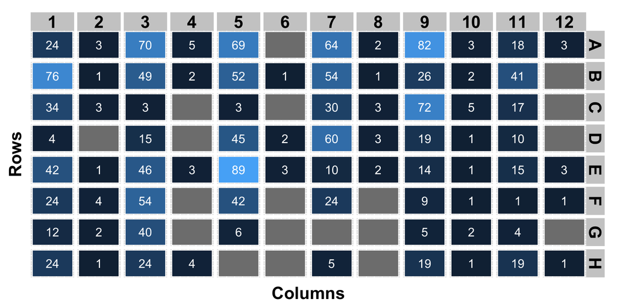

```r
plotTrait(setupSummarized, "n")
```

We can see that the larger populations of worms are, in fact, only present in every other well, row-wise. We can also see wells that are missing data points, as they are colored gray and are missing the numerical annotation. The returned plot is a ggplot2 object and as such can be manipulated using standard ggplot2 functions. This is true for all of the following plotting functions as well. For instance, we can add a title as such:

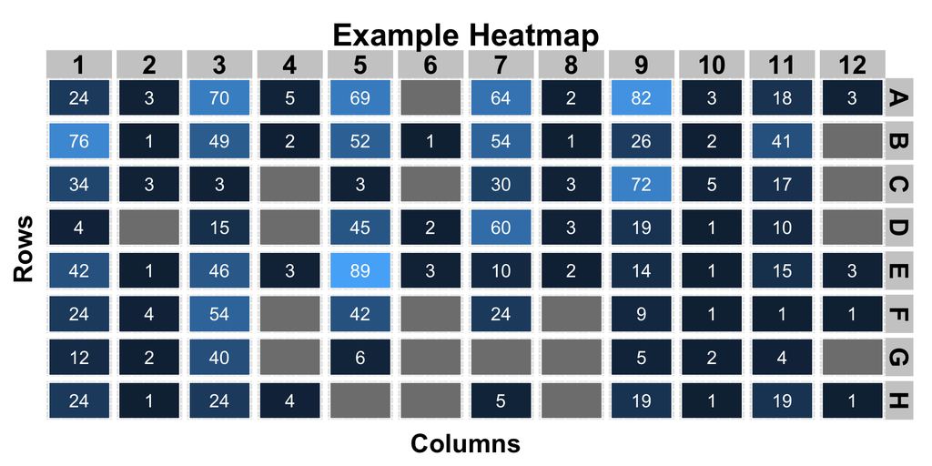

```r
plotTrait(setupSummarized, "n") + ggtitle("Example Heatmap")
```

We are not simply limited to heat maps, however. By plotting the raw data, we can get a better feel for the distributions of the traits. We can plot a histogram of the values in each well:

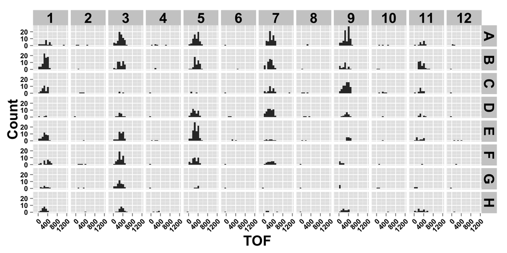

```r
plotTrait(setupRaw, "TOF", type="hist")
```

Or we can plot a scatter plot between two traits:

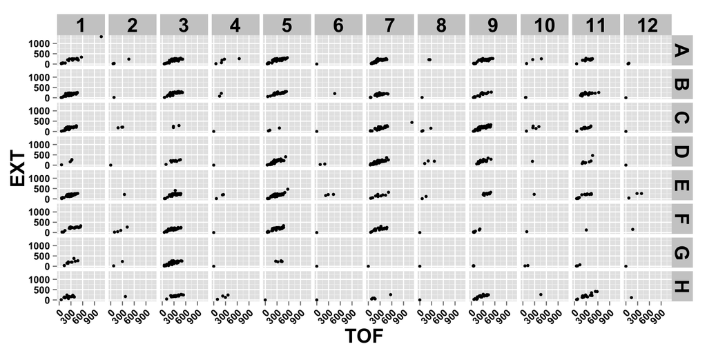

```r
plotTrait(setupRaw, "TOF", "EXT", type="scatter")
```

We may also want to compare how traits differ across plates. Included in the package is a function called `plotCompare` that accomplishes this very task. Here, we’ll compare the distributions of the time-of-flight values between the data in `setupRaw` and a new plate called `scoreRaw`. These two plates will be entered as a list to the first argument in the function. Then, we’ll specify the trait to be compared (`TOF` in this case). Finally we’ll enter in a vector of the plates names as the optional third argument:

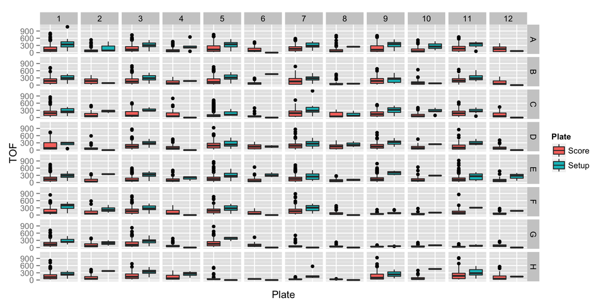

```r
scoreRaw <- plateData2
plotCompare(list(setupRaw, scoreRaw), "TOF", plateNames=c("Setup", "Score"))
```

We can see that side-by-side box plots are plotted for the values in each well. Likewise, we can compare the summarized values between plates by feeding in summarized plate data:

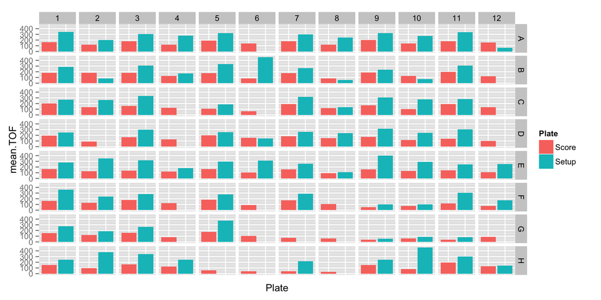

```r
scoreSummarized <- summarizePlate(scoreRaw)
plotCompare(list(setupSummarized, scoreSummarized), "mean.TOF", plateNames=c("Setup", "Score"))
```

In addition, we can also check for correlation between traits both within and across plates using a new function called `plotCorMatrix`. This function will plot a correlation heat map between all of the traits either within or between summarized plates. Here we will examine correlations between traits within the summarized setup data:

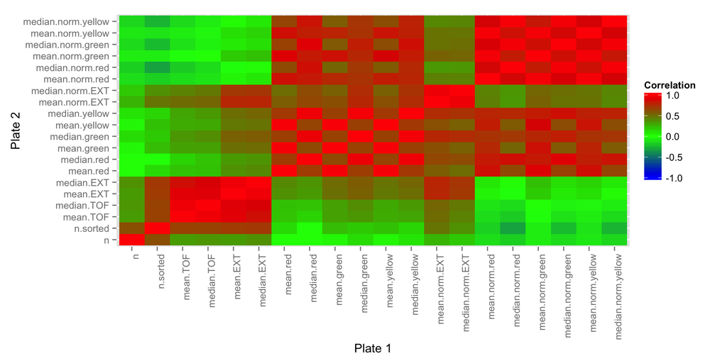

```r
plotCorMatrix(setupSummarized)
```

In the above matrix we can see that some traits are positively correlated, some are negatively correlated, and some are completely uncorrelated. We can also examine these patterns between plates as such:

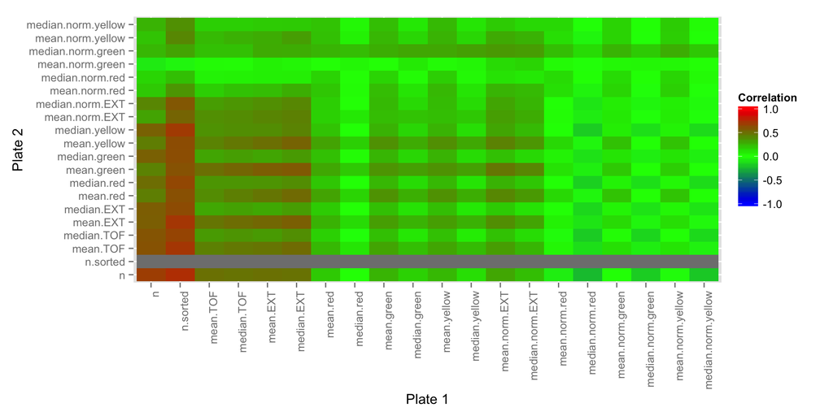

```r
plotCorMatrix(setupSummarized, scoreSummarized)
```

We can now see an instance where all values of a trait (`n.sorted`) were equivalent and therefore the correlation could not be calculated. Tiles for these traits are all set to gray.

If we now transition to some new data, representing an experiment in which drug dose response curves were measured, we can utilize the last plot function in the package, `plotDR`. We will first load in our example data set, called `doseData` into the variable `dosesRaw`. We will then summarize this data, filling in the strains with a 96-element vector corresponding to the names of the strains across a plate, row-wise.

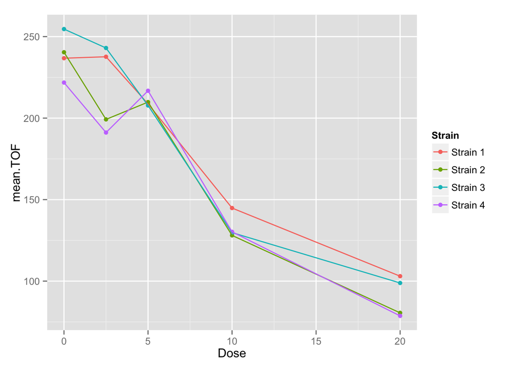

```r
dosesRaw <- doseData
strains <- rep(c("Strain 1", "Strain 2", "Strain 3", "Strain 4"), each=6, times=4)
dosesSummarized <- summarizePlate(dosesRaw, strains)
doses <- rep(c(0,2.5,5,10,20,NA), times=16)
plotDR(dosesSummarized, dosages=doses, trait="mean.TOF")
```

We can see that we now need to include the strains vector when summarizing the data as well as a dosages vector when plotting the dose response. We also might like to see how the strains vary across every trait. We can generate a list of ggplot2 objects using the `plotDR_allTraits` function:

```r
plotList <- plotDR_allTraits(dosesSummarized, dosages=doses)
```

We can even access each plot by name using the scheme below:

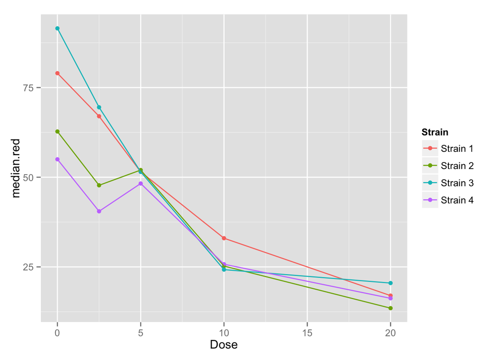

```r
plotList$median.red
```

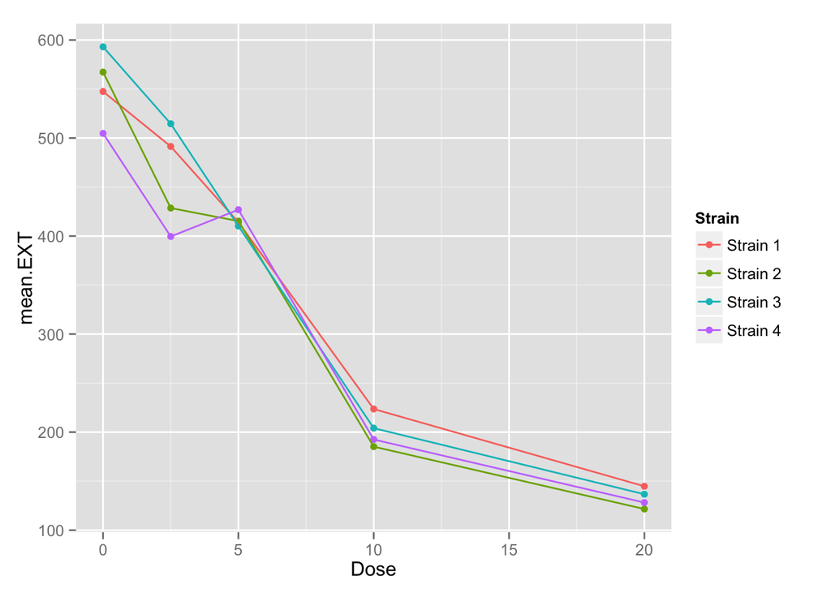

```r
plotList$mean.EXT
```

## Conclusion

The COPASutils package provides quick, streamlined tools for reading, processing, and plotting data resulting from COPAS platform machines. Here we have analyzed data from several different experiments. Of course, analysis pipelines for the data will change from project to project and the pipeline described here may or may not be the best fit for your data. COPASutils provides a very general and flexible work flow for COPAS data and should be easily adaptable to your specific project.